# Human Activity Recognition

Claudia Erika Hernandez Patiño

9/20/2020

Many new devices collect a large amount of data about the personal activity. One thing that people regularly do is quantify how much of a particular activity they do, but they rarely quantify quality. With data from http://groupware.les.inf.puc-rio.br/har that use accelerometers from the belt, forearm, arm, and dumbell of 6 participants. They were asked to perform barbell lifts correctly and incorrectly in 5 different ways

# Data partition and exploration

We used 60% of the data to train and 40% to test.  
As we can see, the first rows seemed to be descriptive data. Although some of the variations may be explained by users, we are more interested in being able to identify any wrong movement. Therefore, we are going to eliminate some of the variables such as user, timestamp, number window, or row number.

```r
set.seed(1294)
w_exce_data<-fread("pml-training.csv",data.table = T)  #https://d396qusza40orc.cloudfront.net/predmachlearn/pml-training.csv
trainIndex <- createDataPartition(w_exce_data$classe, p = .6,
                                  list = FALSE,
                                  times = 1)# partioning data
val_exce <- w_exce_data[-trainIndex]
train_exce <- w_exce_data[trainIndex]
summary(train_exce)
```

```
##        V1         user_name         raw_timestamp_part_1 raw_timestamp_part_2
##  Min.   :    5   Length:11776       Min.   :1.322e+09    Min.   :   294
##  1st Qu.: 4874   Class :character   1st Qu.:1.323e+09    1st Qu.:254512
##  Median : 9800   Mode  :character   Median :1.323e+09    Median :496290
##  Mean   : 9807                      Mean   :1.323e+09    Mean   :500279
##  3rd Qu.:14719                      3rd Qu.:1.323e+09    3rd Qu.:750651
##  Max.   :19622                      Max.   :1.323e+09    Max.   :998801
##
##  cvtd_timestamp      new_window          num_window      roll_belt
##  Length:11776       Length:11776       Min.   :  1.0   Min.   :-28.90
##  Class :character   Class :character   1st Qu.:221.0   1st Qu.:  1.10
##  Mode  :character   Mode  :character   Median :422.0   Median :113.00
##                                        Mean   :429.3   Mean   : 64.11
##                                        3rd Qu.:643.0   3rd Qu.:123.00
##                                        Max.   :864.0   Max.   :162.00
##
##    pitch_belt          yaw_belt       total_accel_belt kurtosis_roll_belt
##  Min.   :-55.8000   Min.   :-179.00   Min.   : 0.00    Min.   :-2.121
##  1st Qu.:  1.7600   1st Qu.: -88.30   1st Qu.: 3.00    1st Qu.:-1.273
##  Median :  5.2300   Median : -14.30   Median :17.00    Median :-0.823
##  Mean   :  0.1831   Mean   : -11.37   Mean   :11.26    Mean   :-0.289
##  3rd Qu.: 14.5000   3rd Qu.:  13.60   3rd Qu.:18.00    3rd Qu.:-0.151
##  Max.   : 60.3000   Max.   : 179.00   Max.   :29.00    Max.   :20.819
##                                                        NA's   :11539
##  kurtosis_picth_belt kurtosis_yaw_belt skewness_roll_belt skewness_roll_belt.1
##  Min.   :-2.190      Min.   : NA       Min.   :-4.683     Min.   :-7.280
##  1st Qu.:-1.180      1st Qu.: NA       1st Qu.:-0.449     1st Qu.:-0.953
##  Median :-0.208      Median : NA       Median : 0.003     Median :-0.006
##  Mean   : 3.662      Mean   :NaN       Mean   :-0.012     Mean   :-0.200
##  3rd Qu.: 3.130      3rd Qu.: NA       3rd Qu.: 0.414     3rd Qu.: 0.632
##  Max.   :54.000      Max.   : NA       Max.   : 3.595     Max.   : 7.348
##  NA's   :11553       NA's   :11776     NA's   :11538      NA's   :11553
##  skewness_yaw_belt max_roll_belt     max_picth_belt   max_yaw_belt
##  Min.   : NA       Min.   :-94.300   Min.   : 3.00   Min.   :-2.100
##  1st Qu.: NA       1st Qu.:-88.000   1st Qu.: 5.00   1st Qu.:-1.300
##  Median : NA       Median : -5.600   Median :18.00   Median :-0.800
##  Mean   :NaN       Mean   : -6.802   Mean   :12.96   Mean   :-0.289
##  3rd Qu.: NA       3rd Qu.: 20.950   3rd Qu.:19.00   3rd Qu.:-0.200
##  Max.   : NA       Max.   :180.000   Max.   :30.00   Max.   :20.800
##  NA's   :11776     NA's   :11533     NA's   :11533   NA's   :11539
```

[output cut: 289 more lines]

```
##  Min.   :-446.00   Min.   :-1280    Min.   :-896.0   Min.   :-973.0
##  1st Qu.:-182.00   1st Qu.: -616    1st Qu.:  -6.0   1st Qu.: 183.0
##  Median : -40.00   Median : -377    Median : 586.0   Median : 511.0
##  Mean   : -54.94   Mean   : -312    Mean   : 377.6   Mean   : 392.2
##  3rd Qu.:  26.00   3rd Qu.:  -72    3rd Qu.: 737.0   3rd Qu.: 654.0
##  Max.   : 287.00   Max.   :  672    Max.   :1480.0   Max.   :1090.0
##
##     classe
##  Length:11776
##  Class :character
##  Mode  :character
##
##
##
##
```

```r
desc_var <- train_exce[,1:7] %>% names()#names of unsusable descriptive variables
```

To have a more stable model, we decided to focus on some common problems, missing values and no variance variables.

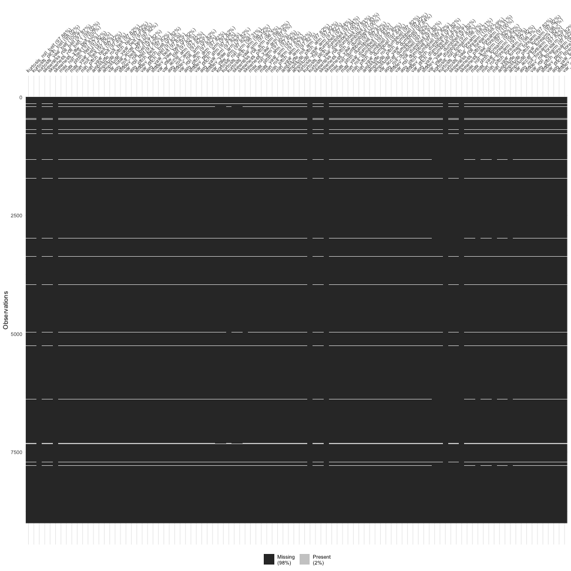

```r
train_exce[,c(desc_var):=NULL]
with_mising<- train_exce[,lapply(.SD, function(col) sum(is.na(col)))] %>% #count nas
  melt() %>%
  .[value>0,variable] %>% # chose columns with at least a missing value
  as.vector()
vis_miss(train_exce[sample(.N,9000),..with_mising]) #
```

```r
train_exce[,c(with_mising):=NULL]
nzv <- nearZeroVar(train_exce, saveMetrics= TRUE)
nzv[nzv$nzv,]
```

```
## [1] freqRatio     percentUnique zeroVar       nzv
## <0 rows> (or 0-length row.names)
```

As seen in the corplot some measurements might be redundant, having variables with high correlation. We are going to try a random forest model with a naive approach, and compare the results preprocessing with PCA.

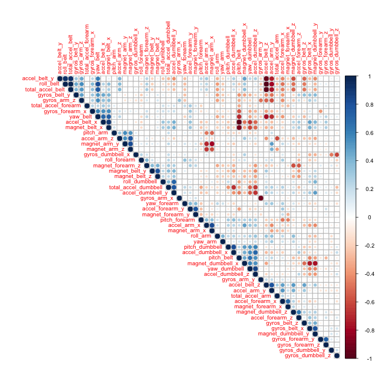

```r
library(corrplot)
library(Hmisc)
cor_var <- train_exce[,-"classe"] %>%
    as.matrix() %>%
  rcorr()
corrplot(cor_var$r,order="hclust",
          type="upper", tl.cex=.8,
         p.mat = cor_var$P, sig.level = 0.01, insig = "blank")
```

```r
library(parallel)
library(doParallel)
train_exce[,classe := as.factor(classe)]
rf_model <- train(classe~. ,train_exce,method="ranger",num.threads = 5)
rf_pca_model <- train(classe~.,train_exce,method="ranger",
                      preProcess = "pca", num.threads = 5)
rf_model$finalModel
```

```
## Ranger result
##
## Call:
##  ranger::ranger(dependent.variable.name = ".outcome", data = x,      mtry = min(param$mtry, ncol(x)), min.node.size = param$min.node.size,      splitrule = as.character(param$splitrule), write.forest = TRUE,      probability = classProbs, ...)
##
## Type:                             Classification
## Number of trees:                  500
## Sample size:                      11776
## Number of independent variables:  52
## Mtry:                             52
## Target node size:                 1
## Variable importance mode:         none
## Splitrule:                        extratrees
## Number of random splits:          1
## OOB prediction error:             0.57 %
```

```r
rf_pca_model$finalModel
```

```
## Ranger result
##
## Call:
##  ranger::ranger(dependent.variable.name = ".outcome", data = x,      mtry = min(param$mtry, ncol(x)), min.node.size = param$min.node.size,      splitrule = as.character(param$splitrule), write.forest = TRUE,      probability = classProbs, ...)
##
## Type:                             Classification
## Number of trees:                  500
## Sample size:                      11776
## Number of independent variables:  26
## Mtry:                             14
## Target node size:                 1
## Variable importance mode:         none
## Splitrule:                        extratrees
## Number of random splits:          1
## OOB prediction error:             2.53 %
```

```r
##Pre process test data
val_exce[,c(desc_var,with_mising):=NULL]
val_exce[,classe := as.factor(classe)]
##acurracy out of sample
confusionMatrix(val_exce[,classe],
                predict.train(rf_model,val_exce))
```

```
## Confusion Matrix and Statistics
##
##           Reference
## Prediction    A    B    C    D    E
##          A 2225    5    1    0    1
##          B    3 1515    0    0    0
##          C    0   12 1355    1    0
##          D    0    0   16 1269    1
##          E    0    0    0    1 1441
##
## Overall Statistics
##
##                Accuracy : 0.9948
##                  95% CI : (0.9929, 0.9962)
##     No Information Rate : 0.284
##     P-Value [Acc > NIR] : < 2.2e-16
##
##                   Kappa : 0.9934
##
##  Mcnemar's Test P-Value : NA
##
## Statistics by Class:
##
##                      Class: A Class: B Class: C Class: D Class: E
## Sensitivity            0.9987   0.9889   0.9876   0.9984   0.9986
## Specificity            0.9988   0.9995   0.9980   0.9974   0.9998
## Pos Pred Value         0.9969   0.9980   0.9905   0.9868   0.9993
## Neg Pred Value         0.9995   0.9973   0.9974   0.9997   0.9997
## Prevalence             0.2840   0.1953   0.1749   0.1620   0.1839
## Detection Rate         0.2836   0.1931   0.1727   0.1617   0.1837
## Detection Prevalence   0.2845   0.1935   0.1744   0.1639   0.1838
## Balanced Accuracy      0.9987   0.9942   0.9928   0.9979   0.9992
```

```r
confusionMatrix(val_exce[,classe],
                predict.train(rf_pca_model,val_exce))
```

```
## Confusion Matrix and Statistics
##
##           Reference
## Prediction    A    B    C    D    E
##          A 2212    9    6    2    3
##          B   26 1471   18    0    3
##          C    1   21 1333   11    2
##          D    3    0   47 1230    6
##          E    2    5    7   10 1418
##
## Overall Statistics
##
##                Accuracy : 0.9768
##                  95% CI : (0.9732, 0.98)
##     No Information Rate : 0.286
##     P-Value [Acc > NIR] : < 2.2e-16
##
##                   Kappa : 0.9707
##
##  Mcnemar's Test P-Value : NA
##
## Statistics by Class:
##
##                      Class: A Class: B Class: C Class: D Class: E
## Sensitivity            0.9857   0.9768   0.9447   0.9816   0.9902
## Specificity            0.9964   0.9926   0.9946   0.9915   0.9963
## Pos Pred Value         0.9910   0.9690   0.9744   0.9565   0.9834
## Neg Pred Value         0.9943   0.9945   0.9880   0.9965   0.9978
## Prevalence             0.2860   0.1919   0.1798   0.1597   0.1825
## Detection Rate         0.2819   0.1875   0.1699   0.1568   0.1807
## Detection Prevalence   0.2845   0.1935   0.1744   0.1639   0.1838
## Balanced Accuracy      0.9911   0.9847   0.9696   0.9866   0.9932
```

As we can see the best model on either out of sample and in sample error is the naive model with good accuracy.

# Conclusion

A simple random forest can predict with good accuracy the type of error while doing a barbell

# Test

```r
test_data <- fread("pml-testing.csv")
test_data[,c(desc_var,with_mising):=NULL]
predict.train(rf_model,test_data)
```

```
##  [1] B A B A A E D B A A B C B A E E A B B B
## Levels: A B C D E
```